# Taller 2 - Punto 2

## Combinación de clasificadores (Ensembles)

Integrantes:

- Juan Camilo Cática
- Ricardo
- Diego Fernando Escobar

## Cargue Librerias

```python
import pandas as pd
import numpy as np
import matplotlib.pyplot as plt
import pandas_profiling #funcion para ver missing values por variables en DF**
from sklearn import tree
from sklearn.model_selection import train_test_split,cross_val_score,cross_validate
from sklearn.metrics import precision_score, recall_score, confusion_matrix, classification_report, accuracy_score, f1_score
from sklearn.preprocessing import LabelEncoder
from sklearn.preprocessing import StandardScaler
from sklearn import preprocessing
from sklearn.metrics import mean_squared_error
from sklearn.model_selection import KFold
import mglearn
import graphviz
import warnings
warnings.filterwarnings('ignore')
import os
os.environ["PATH"] += os.pathsep + 'C:/Program Files (x86)/Graphviz2.38/bin/'
from sklearn.ensemble import RandomForestClassifier
from sklearn.model_selection import GridSearchCV
from sklearn.decomposition import PCA
```

### Funcione para encontrar valores ausentes

```python
def missing_values_table(df):
        mis_val = df.isnull().sum()
        mis_val_percent = 100 * df.isnull().sum()/len(df)
        mis_val_table = pd.concat([mis_val, mis_val_percent], axis=1)
        mis_val_table_ren_columns = mis_val_table.rename(
        columns = {0 : 'Missing Values', 1 : '% of Total Values'})
        return mis_val_table_ren_columns
```

### Funcion para numerizar valores categoricos

```python
def numerizar_var(dataset):
    for c in dataset.columns:
        if dataset[c].dtype == 'object':
            lbl = preprocessing.LabelEncoder()
            lbl.fit(list(dataset[c].values))
            dataset[c] = lbl.transform(list(dataset[c].values))
```

### Funcion para normalziar valores numericos

```python
def normalizar_var(dataset):
    num_cols = dataset.columns[dataset.dtypes.apply(lambda c: np.issubdtype(c, np.number))]
    scaler = StandardScaler()
    dataset[num_cols] = scaler.fit_transform(dataset[num_cols])
```

### Funcion evaluación modelo

```python
def eval_modelo(modelo):
    modelo.fit(X_train, y_train)
    y_pred = modelo.predict(X_test)
    global cm1
    cm1 =  confusion_matrix(y_test, y_pred)
    print ('Train Accuracy:', accuracy_score(y_train, modelo.predict(X_train)))
    print( 'Test Accuracy :', accuracy_score(y_test, y_pred))
    print( 'F1 score +    :', f1_score(y_test, y_pred))
    print( 'Recall +      :', recall_score(y_test, y_pred))
    print('Precision +   :', precision_score(y_test, y_pred))
    print ('\n clasification report:\n', classification_report(y_test, y_pred))
    print ('\n Matriz de Confusion:\n',cm1)
```

```python
def plot_impotancia_atributos(lista_atributos,estimador):
    plt.barh(range(len(lista_atributos)), estimador.feature_importances_, align='center')
    plt.yticks(range(len(lista_atributos)), lista_atributos, rotation = 0)
    plt.xlabel("Importancias de los Atributos")
    plt.ylabel("Atributos")
```

### Carga set de datos

```python
df = pd.read_csv('WA_Fn-UseC_-HR-Employee-Attrition.csv',sep=",")
```

```python
df.head()
```

|  | Age | Attrition | BusinessTravel | DailyRate | Department | DistanceFromHome | Education | EducationField | EmployeeCount | EmployeeNumber | ... | RelationshipSatisfaction | StandardHours | StockOptionLevel | TotalWorkingYears | TrainingTimesLastYear | WorkLifeBalance | YearsAtCompany | YearsInCurrentRole | YearsSinceLastPromotion | YearsWithCurrManager |
| --- | --- | --- | --- | --- | --- | --- | --- | --- | --- | --- | --- | --- | --- | --- | --- | --- | --- | --- | --- | --- | --- |
| 0 | 41 | Yes | Travel_Rarely | 1102 | Sales | 1 | 2 | Life Sciences | 1 | 1 | ... | 1 | 80 | 0 | 8 | 0 | 1 | 6 | 4 | 0 | 5 |
| 1 | 49 | No | Travel_Frequently | 279 | Research & Development | 8 | 1 | Life Sciences | 1 | 2 | ... | 4 | 80 | 1 | 10 | 3 | 3 | 10 | 7 | 1 | 7 |
| 2 | 37 | Yes | Travel_Rarely | 1373 | Research & Development | 2 | 2 | Other | 1 | 4 | ... | 2 | 80 | 0 | 7 | 3 | 3 | 0 | 0 | 0 | 0 |
| 3 | 33 | No | Travel_Frequently | 1392 | Research & Development | 3 | 4 | Life Sciences | 1 | 5 | ... | 3 | 80 | 0 | 8 | 3 | 3 | 8 | 7 | 3 | 0 |
| 4 | 27 | No | Travel_Rarely | 591 | Research & Development | 2 | 1 | Medical | 1 | 7 | ... | 4 | 80 | 1 | 6 | 3 | 3 | 2 | 2 | 2 | 2 |

5 rows × 35 columns

```python
df.describe()
```

|  | Age | DailyRate | DistanceFromHome | Education | EmployeeCount | EmployeeNumber | EnvironmentSatisfaction | HourlyRate | JobInvolvement | JobLevel | ... | RelationshipSatisfaction | StandardHours | StockOptionLevel | TotalWorkingYears | TrainingTimesLastYear | WorkLifeBalance | YearsAtCompany | YearsInCurrentRole | YearsSinceLastPromotion | YearsWithCurrManager |
| --- | --- | --- | --- | --- | --- | --- | --- | --- | --- | --- | --- | --- | --- | --- | --- | --- | --- | --- | --- | --- | --- |
| count | 1470.000000 | 1470.000000 | 1470.000000 | 1470.000000 | 1470.0 | 1470.000000 | 1470.000000 | 1470.000000 | 1470.000000 | 1470.000000 | ... | 1470.000000 | 1470.0 | 1470.000000 | 1470.000000 | 1470.000000 | 1470.000000 | 1470.000000 | 1470.000000 | 1470.000000 | 1470.000000 |
| mean | 36.923810 | 802.485714 | 9.192517 | 2.912925 | 1.0 | 1024.865306 | 2.721769 | 65.891156 | 2.729932 | 2.063946 | ... | 2.712245 | 80.0 | 0.793878 | 11.279592 | 2.799320 | 2.761224 | 7.008163 | 4.229252 | 2.187755 | 4.123129 |
| std | 9.135373 | 403.509100 | 8.106864 | 1.024165 | 0.0 | 602.024335 | 1.093082 | 20.329428 | 0.711561 | 1.106940 | ... | 1.081209 | 0.0 | 0.852077 | 7.780782 | 1.289271 | 0.706476 | 6.126525 | 3.623137 | 3.222430 | 3.568136 |
| min | 18.000000 | 102.000000 | 1.000000 | 1.000000 | 1.0 | 1.000000 | 1.000000 | 30.000000 | 1.000000 | 1.000000 | ... | 1.000000 | 80.0 | 0.000000 | 0.000000 | 0.000000 | 1.000000 | 0.000000 | 0.000000 | 0.000000 | 0.000000 |
| 25% | 30.000000 | 465.000000 | 2.000000 | 2.000000 | 1.0 | 491.250000 | 2.000000 | 48.000000 | 2.000000 | 1.000000 | ... | 2.000000 | 80.0 | 0.000000 | 6.000000 | 2.000000 | 2.000000 | 3.000000 | 2.000000 | 0.000000 | 2.000000 |
| 50% | 36.000000 | 802.000000 | 7.000000 | 3.000000 | 1.0 | 1020.500000 | 3.000000 | 66.000000 | 3.000000 | 2.000000 | ... | 3.000000 | 80.0 | 1.000000 | 10.000000 | 3.000000 | 3.000000 | 5.000000 | 3.000000 | 1.000000 | 3.000000 |
| 75% | 43.000000 | 1157.000000 | 14.000000 | 4.000000 | 1.0 | 1555.750000 | 4.000000 | 83.750000 | 3.000000 | 3.000000 | ... | 4.000000 | 80.0 | 1.000000 | 15.000000 | 3.000000 | 3.000000 | 9.000000 | 7.000000 | 3.000000 | 7.000000 |
| max | 60.000000 | 1499.000000 | 29.000000 | 5.000000 | 1.0 | 2068.000000 | 4.000000 | 100.000000 | 4.000000 | 5.000000 | ... | 4.000000 | 80.0 | 3.000000 | 40.000000 | 6.000000 | 4.000000 | 40.000000 | 18.000000 | 15.000000 | 17.000000 |

8 rows × 26 columns

```python
df.info()
```

```
<class 'pandas.core.frame.DataFrame'>
RangeIndex: 1470 entries, 0 to 1469
Data columns (total 35 columns):
Age                         1470 non-null int64
Attrition                   1470 non-null object
BusinessTravel              1470 non-null object
DailyRate                   1470 non-null int64
Department                  1470 non-null object
DistanceFromHome            1470 non-null int64
Education                   1470 non-null int64
EducationField              1470 non-null object
EmployeeCount               1470 non-null int64
EmployeeNumber              1470 non-null int64
EnvironmentSatisfaction     1470 non-null int64
Gender                      1470 non-null object
HourlyRate                  1470 non-null int64
JobInvolvement              1470 non-null int64
JobLevel                    1470 non-null int64
JobRole                     1470 non-null object
JobSatisfaction             1470 non-null int64
MaritalStatus               1470 non-null object
MonthlyIncome               1470 non-null int64
MonthlyRate                 1470 non-null int64
NumCompaniesWorked          1470 non-null int64
Over18                      1470 non-null object
OverTime                    1470 non-null object
PercentSalaryHike           1470 non-null int64
PerformanceRating           1470 non-null int64
RelationshipSatisfaction    1470 non-null int64
StandardHours               1470 non-null int64
StockOptionLevel            1470 non-null int64
TotalWorkingYears           1470 non-null int64
TrainingTimesLastYear       1470 non-null int64
WorkLifeBalance             1470 non-null int64
YearsAtCompany              1470 non-null int64
YearsInCurrentRole          1470 non-null int64
YearsSinceLastPromotion     1470 non-null int64
YearsWithCurrManager        1470 non-null int64
dtypes: int64(26), object(9)
memory usage: 402.1+ KB
```

```python
df.shape
```

```
(1470, 35)
```

### Histograma atributos numéricos

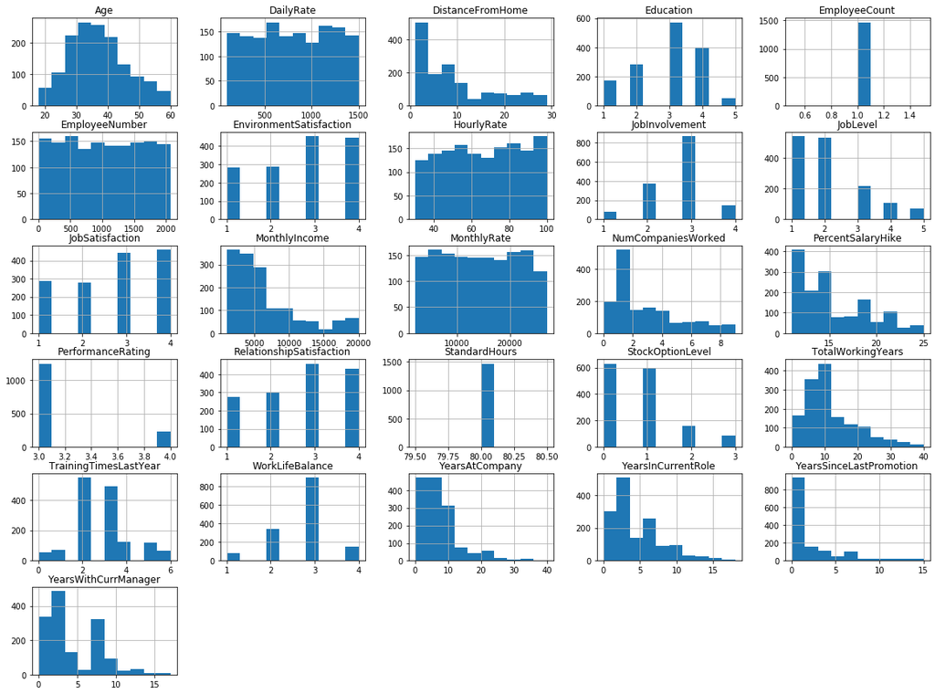

```python
# Se pueden generar los histogramas
df.hist(bins=10, figsize=(20,15));
```

```python
#valores omitidos por variable
missing_values_table(df)
```

|  | Missing Values | % of Total Values |
| --- | --- | --- |
| Age | 0 | 0.0 |
| Attrition | 0 | 0.0 |
| BusinessTravel | 0 | 0.0 |
| DailyRate | 0 | 0.0 |
| Department | 0 | 0.0 |
| DistanceFromHome | 0 | 0.0 |
| Education | 0 | 0.0 |
| EducationField | 0 | 0.0 |
| EmployeeCount | 0 | 0.0 |
| EmployeeNumber | 0 | 0.0 |
| EnvironmentSatisfaction | 0 | 0.0 |
| Gender | 0 | 0.0 |
| HourlyRate | 0 | 0.0 |
| JobInvolvement | 0 | 0.0 |
| JobLevel | 0 | 0.0 |
| JobRole | 0 | 0.0 |
| JobSatisfaction | 0 | 0.0 |
| MaritalStatus | 0 | 0.0 |
| MonthlyIncome | 0 | 0.0 |
| MonthlyRate | 0 | 0.0 |
| NumCompaniesWorked | 0 | 0.0 |
| Over18 | 0 | 0.0 |
| OverTime | 0 | 0.0 |
| PercentSalaryHike | 0 | 0.0 |
| PerformanceRating | 0 | 0.0 |
| RelationshipSatisfaction | 0 | 0.0 |
| StandardHours | 0 | 0.0 |
| StockOptionLevel | 0 | 0.0 |
| TotalWorkingYears | 0 | 0.0 |
| TrainingTimesLastYear | 0 | 0.0 |
| WorkLifeBalance | 0 | 0.0 |
| YearsAtCompany | 0 | 0.0 |
| YearsInCurrentRole | 0 | 0.0 |
| YearsSinceLastPromotion | 0 | 0.0 |
| YearsWithCurrManager | 0 | 0.0 |

```python
#dateccion duplicadso
df[df.duplicated()]
```

|  | Age | Attrition | BusinessTravel | DailyRate | Department | DistanceFromHome | Education | EducationField | EmployeeCount | EmployeeNumber | ... | RelationshipSatisfaction | StandardHours | StockOptionLevel | TotalWorkingYears | TrainingTimesLastYear | WorkLifeBalance | YearsAtCompany | YearsInCurrentRole | YearsSinceLastPromotion | YearsWithCurrManager |
| --- | --- | --- | --- | --- | --- | --- | --- | --- | --- | --- | --- | --- | --- | --- | --- | --- | --- | --- | --- | --- | --- |

0 rows × 35 columns

# Descripción general de datos

#### Dataste conformado por 1470 instancias y 35 atributos, numéricos y categóricos.

#### Atributo clase: Attrition. Categórico, binario: Yes, No.

#### Atributo Identificador: EmployeeNumber. Numérico.

# Preprocesamiento de Datos

### Estadísticas Básicas y Correlación de atributos

Overview

Dataset info

| Number of variables | 35 |
| --- | --- |
| Number of observations | 1470 |
| Total Missing (%) | 0.0% |
| Total size in memory | 402.1 KiB |
| Average record size in memory | 280.1 B |

Variables types

| Numeric | 22 |
| --- | --- |
| Categorical | 8 |
| Boolean | 1 |
| Date | 0 |
| Text (Unique) | 0 |
| Rejected | 4 |
| Unsupported | 0 |

Warnings

- `EmployeeCount` has constant value 1 Rejected

- `MonthlyIncome` is highly correlated with `JobLevel` (ρ = 0.9503) Rejected

- `NumCompaniesWorked` has 197 / 13.4% zeros Zeros

- `Over18` has constant value Y Rejected

- `StandardHours` has constant value 80 Rejected

- `StockOptionLevel` has 631 / 42.9% zeros Zeros

- `TrainingTimesLastYear` has 54 / 3.7% zeros Zeros

- `YearsAtCompany` has 44 / 3.0% zeros Zeros

- `YearsInCurrentRole` has 244 / 16.6% zeros Zeros

- `YearsSinceLastPromotion` has 581 / 39.5% zeros Zeros

- `YearsWithCurrManager` has 263 / 17.9% zeros Zeros

Variables

Age  
Numeric

| Distinct count | 43 |
| --- | --- |
| Unique (%) | 2.9% |
| Missing (%) | 0.0% |
| Missing (n) | 0 |
| Infinite (%) | 0.0% |
| Infinite (n) | 0 |

| Mean | 36.924 |
| --- | --- |
| Minimum | 18 |
| Maximum | 60 |
| Zeros (%) | 0.0% |

Toggle details

**Statistics**

Quantile statistics

| Minimum | 18 |
| --- | --- |
| 5-th percentile | 24 |
| Q1 | 30 |
| Median | 36 |
| Q3 | 43 |
| 95-th percentile | 54 |
| Maximum | 60 |
| Range | 42 |
| Interquartile range | 13 |

Descriptive statistics

| Standard deviation | 9.1354 |
| --- | --- |
| Coef of variation | 0.24741 |
| Kurtosis | -0.40415 |
| Mean | 36.924 |
| MAD | 7.4098 |
| Skewness | 0.41329 |
| Sum | 54278 |
| Variance | 83.455 |
| Memory size | 11.6 KiB |

**Histogram**

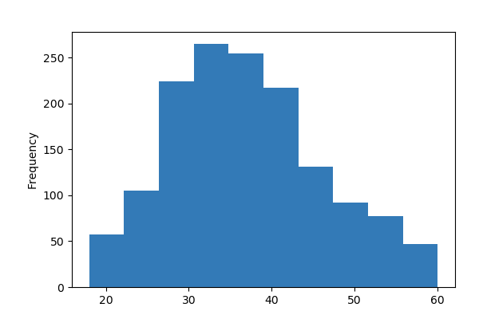

**Common Values**

| Value | Count | Frequency (%) |  |
| --- | --- | --- | --- |
| 35 | 78 | 5.3% |  |
| 34 | 77 | 5.2% |  |
| 31 | 69 | 4.7% |  |
| 36 | 69 | 4.7% |  |
| 29 | 68 | 4.6% |  |
| 32 | 61 | 4.1% |  |
| 30 | 60 | 4.1% |  |
| 33 | 58 | 3.9% |  |
| 38 | 58 | 3.9% |  |
| 40 | 57 | 3.9% |  |
| Other values (33) | 815 | 55.4% |  |

**Extreme Values**

Minimum 5 values

| Value | Count | Frequency (%) |  |
| --- | --- | --- | --- |
| 18 | 8 | 0.5% |  |
| 19 | 9 | 0.6% |  |
| 20 | 11 | 0.7% |  |
| 21 | 13 | 0.9% |  |
| 22 | 16 | 1.1% |  |

Maximum 5 values

| Value | Count | Frequency (%) |  |
| --- | --- | --- | --- |
| 56 | 14 | 1.0% |  |
| 57 | 4 | 0.3% |  |
| 58 | 14 | 1.0% |  |
| 59 | 10 | 0.7% |  |
| 60 | 5 | 0.3% |  |

Attrition  
Categorical

| Distinct count | 2 |
| --- | --- |
| Unique (%) | 0.1% |
| Missing (%) | 0.0% |
| Missing (n) | 0 |

| No | 1233 |
| --- | --- |
| Yes | 237 |

Toggle details

| Value | Count | Frequency (%) |  |
| --- | --- | --- | --- |
| No | 1233 | 83.9% |  |
| Yes | 237 | 16.1% |  |

BusinessTravel  
Categorical

| Distinct count | 3 |
| --- | --- |
| Unique (%) | 0.2% |
| Missing (%) | 0.0% |
| Missing (n) | 0 |

| Travel_Rarely | 1043 |
| --- | --- |
| Travel_Frequently | 277 |
| Non-Travel | 150 |

Toggle details

| Value | Count | Frequency (%) |  |
| --- | --- | --- | --- |
| Travel_Rarely | 1043 | 71.0% |  |
| Travel_Frequently | 277 | 18.8% |  |
| Non-Travel | 150 | 10.2% |  |

DailyRate  
Numeric

| Distinct count | 886 |
| --- | --- |
| Unique (%) | 60.3% |
| Missing (%) | 0.0% |
| Missing (n) | 0 |
| Infinite (%) | 0.0% |
| Infinite (n) | 0 |

| Mean | 802.49 |
| --- | --- |
| Minimum | 102 |
| Maximum | 1499 |
| Zeros (%) | 0.0% |

Toggle details

**Statistics**

Quantile statistics

| Minimum | 102 |
| --- | --- |
| 5-th percentile | 165.35 |
| Q1 | 465 |
| Median | 802 |
| Q3 | 1157 |
| 95-th percentile | 1424.1 |
| Maximum | 1499 |
| Range | 1397 |
| Interquartile range | 692 |

Descriptive statistics

| Standard deviation | 403.51 |
| --- | --- |
| Coef of variation | 0.50282 |
| Kurtosis | -1.2038 |
| Mean | 802.49 |
| MAD | 350.25 |
| Skewness | -0.0035186 |
| Sum | 1179654 |
| Variance | 162820 |
| Memory size | 11.6 KiB |

**Histogram**

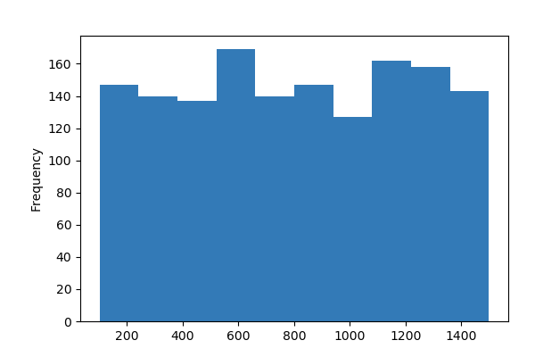

**Common Values**

| Value | Count | Frequency (%) |  |
| --- | --- | --- | --- |
| 691 | 6 | 0.4% |  |
| 1082 | 5 | 0.3% |  |
| 329 | 5 | 0.3% |  |
| 1329 | 5 | 0.3% |  |
| 530 | 5 | 0.3% |  |
| 408 | 5 | 0.3% |  |
| 715 | 4 | 0.3% |  |
| 589 | 4 | 0.3% |  |
| 906 | 4 | 0.3% |  |
| 350 | 4 | 0.3% |  |
| Other values (876) | 1423 | 96.8% |  |

**Extreme Values**

Minimum 5 values

| Value | Count | Frequency (%) |  |
| --- | --- | --- | --- |
| 102 | 1 | 0.1% |  |
| 103 | 1 | 0.1% |  |
| 104 | 1 | 0.1% |  |
| 105 | 1 | 0.1% |  |
| 106 | 1 | 0.1% |  |

Maximum 5 values

| Value | Count | Frequency (%) |  |
| --- | --- | --- | --- |
| 1492 | 1 | 0.1% |  |
| 1495 | 3 | 0.2% |  |
| 1496 | 2 | 0.1% |  |
| 1498 | 1 | 0.1% |  |
| 1499 | 1 | 0.1% |  |

Department  
Categorical

| Distinct count | 3 |
| --- | --- |
| Unique (%) | 0.2% |
| Missing (%) | 0.0% |
| Missing (n) | 0 |

| Research & Development | 961 |
| --- | --- |
| Sales | 446 |
| Human Resources | 63 |

Toggle details

| Value | Count | Frequency (%) |  |
| --- | --- | --- | --- |
| Research & Development | 961 | 65.4% |  |
| Sales | 446 | 30.3% |  |
| Human Resources | 63 | 4.3% |  |

DistanceFromHome  
Numeric

| Distinct count | 29 |
| --- | --- |
| Unique (%) | 2.0% |
| Missing (%) | 0.0% |
| Missing (n) | 0 |
| Infinite (%) | 0.0% |
| Infinite (n) | 0 |

| Mean | 9.1925 |
| --- | --- |
| Minimum | 1 |
| Maximum | 29 |
| Zeros (%) | 0.0% |

Toggle details

**Statistics**

Quantile statistics

| Minimum | 1 |
| --- | --- |
| 5-th percentile | 1 |
| Q1 | 2 |
| Median | 7 |
| Q3 | 14 |
| 95-th percentile | 26 |
| Maximum | 29 |
| Range | 28 |
| Interquartile range | 12 |

Descriptive statistics

| Standard deviation | 8.1069 |
| --- | --- |
| Coef of variation | 0.8819 |
| Kurtosis | -0.22483 |
| Mean | 9.1925 |
| MAD | 6.5727 |
| Skewness | 0.95812 |
| Sum | 13513 |
| Variance | 65.721 |
| Memory size | 11.6 KiB |

**Histogram**

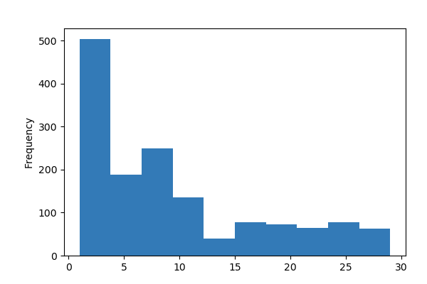

**Common Values**

| Value | Count | Frequency (%) |  |
| --- | --- | --- | --- |
| 2 | 211 | 14.4% |  |
| 1 | 208 | 14.1% |  |
| 10 | 86 | 5.9% |  |
| 9 | 85 | 5.8% |  |
| 3 | 84 | 5.7% |  |
| 7 | 84 | 5.7% |  |
| 8 | 80 | 5.4% |  |
| 5 | 65 | 4.4% |  |
| 4 | 64 | 4.4% |  |
| 6 | 59 | 4.0% |  |
| Other values (19) | 444 | 30.2% |  |

**Extreme Values**

Minimum 5 values

| Value | Count | Frequency (%) |  |
| --- | --- | --- | --- |
| 1 | 208 | 14.1% |  |
| 2 | 211 | 14.4% |  |
| 3 | 84 | 5.7% |  |
| 4 | 64 | 4.4% |  |
| 5 | 65 | 4.4% |  |

Maximum 5 values

| Value | Count | Frequency (%) |  |
| --- | --- | --- | --- |
| 25 | 25 | 1.7% |  |
| 26 | 25 | 1.7% |  |
| 27 | 12 | 0.8% |  |
| 28 | 23 | 1.6% |  |
| 29 | 27 | 1.8% |  |

Education  
Numeric

| Distinct count | 5 |
| --- | --- |
| Unique (%) | 0.3% |
| Missing (%) | 0.0% |
| Missing (n) | 0 |
| Infinite (%) | 0.0% |
| Infinite (n) | 0 |

| Mean | 2.9129 |
| --- | --- |
| Minimum | 1 |
| Maximum | 5 |
| Zeros (%) | 0.0% |

Toggle details

**Statistics**

Quantile statistics

| Minimum | 1 |
| --- | --- |
| 5-th percentile | 1 |
| Q1 | 2 |
| Median | 3 |
| Q3 | 4 |
| 95-th percentile | 4 |
| Maximum | 5 |
| Range | 4 |
| Interquartile range | 2 |

Descriptive statistics

| Standard deviation | 1.0242 |
| --- | --- |
| Coef of variation | 0.35159 |
| Kurtosis | -0.55911 |
| Mean | 2.9129 |
| MAD | 0.79271 |
| Skewness | -0.28968 |
| Sum | 4282 |
| Variance | 1.0489 |
| Memory size | 11.6 KiB |

**Histogram**

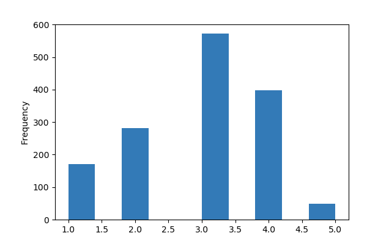

**Common Values**

| Value | Count | Frequency (%) |  |
| --- | --- | --- | --- |
| 3 | 572 | 38.9% |  |
| 4 | 398 | 27.1% |  |
| 2 | 282 | 19.2% |  |
| 1 | 170 | 11.6% |  |
| 5 | 48 | 3.3% |  |

**Extreme Values**

Minimum 5 values

| Value | Count | Frequency (%) |  |
| --- | --- | --- | --- |
| 1 | 170 | 11.6% |  |
| 2 | 282 | 19.2% |  |
| 3 | 572 | 38.9% |  |
| 4 | 398 | 27.1% |  |
| 5 | 48 | 3.3% |  |

Maximum 5 values

| Value | Count | Frequency (%) |  |
| --- | --- | --- | --- |
| 1 | 170 | 11.6% |  |
| 2 | 282 | 19.2% |  |
| 3 | 572 | 38.9% |  |
| 4 | 398 | 27.1% |  |
| 5 | 48 | 3.3% |  |

EducationField  
Categorical

| Distinct count | 6 |
| --- | --- |
| Unique (%) | 0.4% |
| Missing (%) | 0.0% |
| Missing (n) | 0 |

| Life Sciences | 606 |
| --- | --- |
| Medical | 464 |
| Marketing | 159 |
| Other values (3) | 241 |

Toggle details

| Value | Count | Frequency (%) |  |
| --- | --- | --- | --- |
| Life Sciences | 606 | 41.2% |  |
| Medical | 464 | 31.6% |  |
| Marketing | 159 | 10.8% |  |
| Technical Degree | 132 | 9.0% |  |
| Other | 82 | 5.6% |  |
| Human Resources | 27 | 1.8% |  |

EmployeeCount  
Constant

*This variable is constant and should be ignored for analysis*

| Constant value | 1 |
| --- | --- |

EmployeeNumber  
Numeric

| Distinct count | 1470 |
| --- | --- |
| Unique (%) | 100.0% |
| Missing (%) | 0.0% |
| Missing (n) | 0 |
| Infinite (%) | 0.0% |
| Infinite (n) | 0 |

| Mean | 1024.9 |
| --- | --- |
| Minimum | 1 |
| Maximum | 2068 |
| Zeros (%) | 0.0% |

Toggle details

**Statistics**

Quantile statistics

| Minimum | 1 |
| --- | --- |
| 5-th percentile | 96.45 |
| Q1 | 491.25 |
| Median | 1020.5 |
| Q3 | 1555.8 |
| 95-th percentile | 1967.5 |
| Maximum | 2068 |
| Range | 2067 |
| Interquartile range | 1064.5 |

Descriptive statistics

| Standard deviation | 602.02 |
| --- | --- |
| Coef of variation | 0.58742 |
| Kurtosis | -1.2232 |
| Mean | 1024.9 |
| MAD | 522.41 |
| Skewness | 0.016574 |
| Sum | 1506552 |
| Variance | 362430 |
| Memory size | 11.6 KiB |

**Histogram**

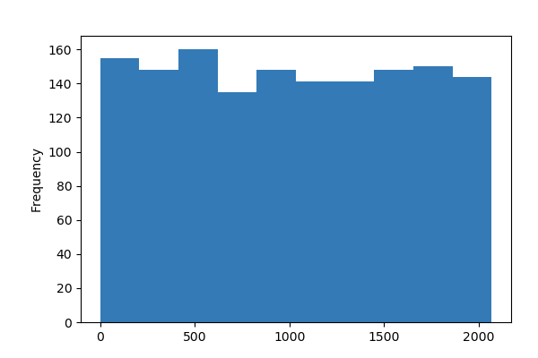

**Common Values**

| Value | Count | Frequency (%) |  |
| --- | --- | --- | --- |
| 2046 | 1 | 0.1% |  |
| 641 | 1 | 0.1% |  |
| 644 | 1 | 0.1% |  |
| 645 | 1 | 0.1% |  |
| 647 | 1 | 0.1% |  |
| 648 | 1 | 0.1% |  |
| 649 | 1 | 0.1% |  |
| 650 | 1 | 0.1% |  |
| 652 | 1 | 0.1% |  |
| 653 | 1 | 0.1% |  |
| Other values (1460) | 1460 | 99.3% |  |

**Extreme Values**

Minimum 5 values

| Value | Count | Frequency (%) |  |
| --- | --- | --- | --- |
| 1 | 1 | 0.1% |  |
| 2 | 1 | 0.1% |  |
| 4 | 1 | 0.1% |  |
| 5 | 1 | 0.1% |  |
| 7 | 1 | 0.1% |  |

Maximum 5 values

| Value | Count | Frequency (%) |  |
| --- | --- | --- | --- |
| 2061 | 1 | 0.1% |  |
| 2062 | 1 | 0.1% |  |
| 2064 | 1 | 0.1% |  |
| 2065 | 1 | 0.1% |  |
| 2068 | 1 | 0.1% |  |

EnvironmentSatisfaction  
Numeric

| Distinct count | 4 |
| --- | --- |
| Unique (%) | 0.3% |
| Missing (%) | 0.0% |
| Missing (n) | 0 |
| Infinite (%) | 0.0% |
| Infinite (n) | 0 |

| Mean | 2.7218 |
| --- | --- |
| Minimum | 1 |
| Maximum | 4 |
| Zeros (%) | 0.0% |

Toggle details

**Statistics**

Quantile statistics

| Minimum | 1 |
| --- | --- |
| 5-th percentile | 1 |
| Q1 | 2 |
| Median | 3 |
| Q3 | 4 |
| 95-th percentile | 4 |
| Maximum | 4 |
| Range | 3 |
| Interquartile range | 2 |

Descriptive statistics

| Standard deviation | 1.0931 |
| --- | --- |
| Coef of variation | 0.40161 |
| Kurtosis | -1.2025 |
| Mean | 2.7218 |
| MAD | 0.94712 |
| Skewness | -0.32165 |
| Sum | 4001 |
| Variance | 1.1948 |
| Memory size | 11.6 KiB |

**Histogram**

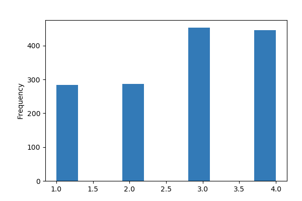

**Common Values**

| Value | Count | Frequency (%) |  |
| --- | --- | --- | --- |
| 3 | 453 | 30.8% |  |
| 4 | 446 | 30.3% |  |
| 2 | 287 | 19.5% |  |
| 1 | 284 | 19.3% |  |

**Extreme Values**

Minimum 5 values

| Value | Count | Frequency (%) |  |
| --- | --- | --- | --- |
| 1 | 284 | 19.3% |  |
| 2 | 287 | 19.5% |  |
| 3 | 453 | 30.8% |  |
| 4 | 446 | 30.3% |  |

Maximum 5 values

| Value | Count | Frequency (%) |  |
| --- | --- | --- | --- |
| 1 | 284 | 19.3% |  |
| 2 | 287 | 19.5% |  |
| 3 | 453 | 30.8% |  |
| 4 | 446 | 30.3% |  |

Gender  
Categorical

| Distinct count | 2 |
| --- | --- |
| Unique (%) | 0.1% |
| Missing (%) | 0.0% |
| Missing (n) | 0 |

| Male | 882 |
| --- | --- |
| Female | 588 |

Toggle details

| Value | Count | Frequency (%) |  |
| --- | --- | --- | --- |
| Male | 882 | 60.0% |  |
| Female | 588 | 40.0% |  |

HourlyRate  
Numeric

| Distinct count | 71 |
| --- | --- |
| Unique (%) | 4.8% |
| Missing (%) | 0.0% |
| Missing (n) | 0 |
| Infinite (%) | 0.0% |
| Infinite (n) | 0 |

| Mean | 65.891 |
| --- | --- |
| Minimum | 30 |
| Maximum | 100 |
| Zeros (%) | 0.0% |

Toggle details

**Statistics**

Quantile statistics

| Minimum | 30 |
| --- | --- |
| 5-th percentile | 33 |
| Q1 | 48 |
| Median | 66 |
| Q3 | 83.75 |
| 95-th percentile | 97 |
| Maximum | 100 |
| Range | 70 |
| Interquartile range | 35.75 |

Descriptive statistics

| Standard deviation | 20.329 |
| --- | --- |
| Coef of variation | 0.30853 |
| Kurtosis | -1.1964 |
| Mean | 65.891 |
| MAD | 17.649 |
| Skewness | -0.032311 |
| Sum | 96860 |
| Variance | 413.29 |
| Memory size | 11.6 KiB |

**Histogram**

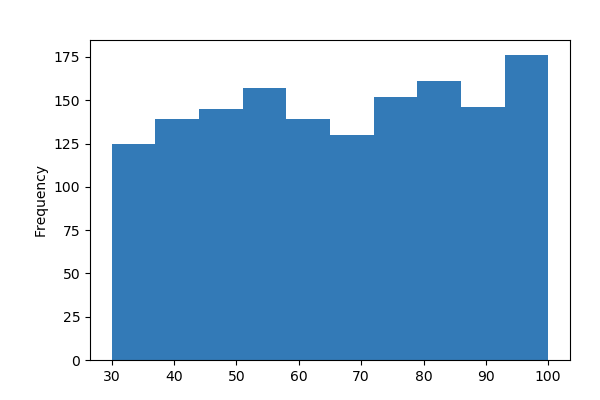

**Common Values**

| Value | Count | Frequency (%) |  |
| --- | --- | --- | --- |
| 66 | 29 | 2.0% |  |
| 42 | 28 | 1.9% |  |
| 98 | 28 | 1.9% |  |
| 48 | 28 | 1.9% |  |
| 84 | 28 | 1.9% |  |
| 79 | 27 | 1.8% |  |
| 96 | 27 | 1.8% |  |
| 57 | 27 | 1.8% |  |
| 52 | 26 | 1.8% |  |
| 87 | 26 | 1.8% |  |
| Other values (61) | 1196 | 81.4% |  |

**Extreme Values**

Minimum 5 values

| Value | Count | Frequency (%) |  |
| --- | --- | --- | --- |
| 30 | 19 | 1.3% |  |
| 31 | 15 | 1.0% |  |
| 32 | 24 | 1.6% |  |
| 33 | 19 | 1.3% |  |
| 34 | 12 | 0.8% |  |

Maximum 5 values

| Value | Count | Frequency (%) |  |
| --- | --- | --- | --- |
| 96 | 27 | 1.8% |  |
| 97 | 21 | 1.4% |  |
| 98 | 28 | 1.9% |  |
| 99 | 20 | 1.4% |  |
| 100 | 19 | 1.3% |  |

JobInvolvement  
Numeric

| Distinct count | 4 |
| --- | --- |
| Unique (%) | 0.3% |
| Missing (%) | 0.0% |
| Missing (n) | 0 |
| Infinite (%) | 0.0% |
| Infinite (n) | 0 |

| Mean | 2.7299 |
| --- | --- |
| Minimum | 1 |
| Maximum | 4 |
| Zeros (%) | 0.0% |

Toggle details

**Statistics**

Quantile statistics

| Minimum | 1 |
| --- | --- |
| 5-th percentile | 1 |
| Q1 | 2 |
| Median | 3 |
| Q3 | 3 |
| 95-th percentile | 4 |
| Maximum | 4 |
| Range | 3 |
| Interquartile range | 1 |

Descriptive statistics

| Standard deviation | 0.71156 |
| --- | --- |
| Coef of variation | 0.26065 |
| Kurtosis | 0.271 |
| Mean | 2.7299 |
| MAD | 0.56777 |
| Skewness | -0.49842 |
| Sum | 4013 |
| Variance | 0.50632 |
| Memory size | 11.6 KiB |

**Histogram**

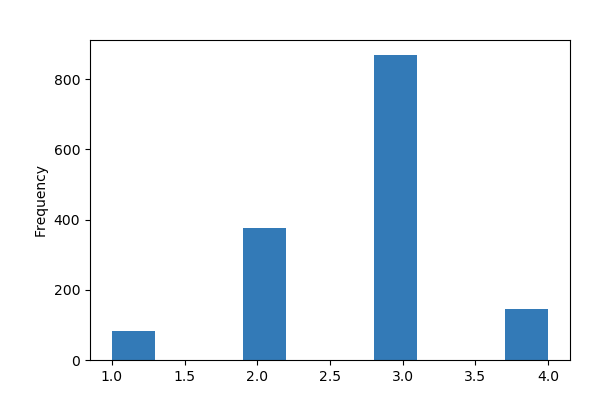

**Common Values**

| Value | Count | Frequency (%) |  |
| --- | --- | --- | --- |
| 3 | 868 | 59.0% |  |
| 2 | 375 | 25.5% |  |
| 4 | 144 | 9.8% |  |
| 1 | 83 | 5.6% |  |

**Extreme Values**

Minimum 5 values

| Value | Count | Frequency (%) |  |
| --- | --- | --- | --- |
| 1 | 83 | 5.6% |  |
| 2 | 375 | 25.5% |  |
| 3 | 868 | 59.0% |  |
| 4 | 144 | 9.8% |  |

Maximum 5 values

| Value | Count | Frequency (%) |  |
| --- | --- | --- | --- |
| 1 | 83 | 5.6% |  |
| 2 | 375 | 25.5% |  |
| 3 | 868 | 59.0% |  |
| 4 | 144 | 9.8% |  |

JobLevel  
Numeric

| Distinct count | 5 |
| --- | --- |
| Unique (%) | 0.3% |
| Missing (%) | 0.0% |
| Missing (n) | 0 |
| Infinite (%) | 0.0% |
| Infinite (n) | 0 |

| Mean | 2.0639 |
| --- | --- |
| Minimum | 1 |
| Maximum | 5 |
| Zeros (%) | 0.0% |

Toggle details

**Statistics**

Quantile statistics

| Minimum | 1 |
| --- | --- |
| 5-th percentile | 1 |
| Q1 | 1 |
| Median | 2 |
| Q3 | 3 |
| 95-th percentile | 4 |
| Maximum | 5 |
| Range | 4 |
| Interquartile range | 2 |

Descriptive statistics

| Standard deviation | 1.1069 |
| --- | --- |
| Coef of variation | 0.53632 |
| Kurtosis | 0.39915 |
| Mean | 2.0639 |
| MAD | 0.83248 |
| Skewness | 1.0254 |
| Sum | 3034 |
| Variance | 1.2253 |
| Memory size | 11.6 KiB |

**Histogram**

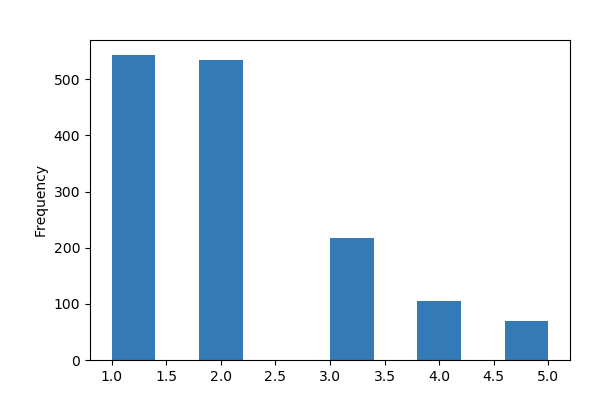

**Common Values**

| Value | Count | Frequency (%) |  |
| --- | --- | --- | --- |
| 1 | 543 | 36.9% |  |
| 2 | 534 | 36.3% |  |
| 3 | 218 | 14.8% |  |
| 4 | 106 | 7.2% |  |
| 5 | 69 | 4.7% |  |

**Extreme Values**

Minimum 5 values

| Value | Count | Frequency (%) |  |
| --- | --- | --- | --- |
| 1 | 543 | 36.9% |  |
| 2 | 534 | 36.3% |  |
| 3 | 218 | 14.8% |  |
| 4 | 106 | 7.2% |  |
| 5 | 69 | 4.7% |  |

Maximum 5 values

| Value | Count | Frequency (%) |  |
| --- | --- | --- | --- |
| 1 | 543 | 36.9% |  |
| 2 | 534 | 36.3% |  |
| 3 | 218 | 14.8% |  |
| 4 | 106 | 7.2% |  |
| 5 | 69 | 4.7% |  |

JobRole  
Categorical

| Distinct count | 9 |
| --- | --- |
| Unique (%) | 0.6% |
| Missing (%) | 0.0% |
| Missing (n) | 0 |

| Sales Executive | 326 |
| --- | --- |
| Research Scientist | 292 |
| Laboratory Technician | 259 |
| Other values (6) | 593 |

Toggle details

| Value | Count | Frequency (%) |  |
| --- | --- | --- | --- |
| Sales Executive | 326 | 22.2% |  |
| Research Scientist | 292 | 19.9% |  |
| Laboratory Technician | 259 | 17.6% |  |
| Manufacturing Director | 145 | 9.9% |  |
| Healthcare Representative | 131 | 8.9% |  |
| Manager | 102 | 6.9% |  |
| Sales Representative | 83 | 5.6% |  |
| Research Director | 80 | 5.4% |  |
| Human Resources | 52 | 3.5% |  |

JobSatisfaction  
Numeric

| Distinct count | 4 |
| --- | --- |
| Unique (%) | 0.3% |
| Missing (%) | 0.0% |
| Missing (n) | 0 |
| Infinite (%) | 0.0% |
| Infinite (n) | 0 |

| Mean | 2.7286 |
| --- | --- |
| Minimum | 1 |
| Maximum | 4 |
| Zeros (%) | 0.0% |

Toggle details

**Statistics**

Quantile statistics

| Minimum | 1 |
| --- | --- |
| 5-th percentile | 1 |
| Q1 | 2 |
| Median | 3 |
| Q3 | 4 |
| 95-th percentile | 4 |
| Maximum | 4 |
| Range | 3 |
| Interquartile range | 2 |

Descriptive statistics

| Standard deviation | 1.1028 |
| --- | --- |
| Coef of variation | 0.40418 |
| Kurtosis | -1.2222 |
| Mean | 2.7286 |
| MAD | 0.95722 |
| Skewness | -0.32967 |
| Sum | 4011 |
| Variance | 1.2163 |
| Memory size | 11.6 KiB |

**Histogram**

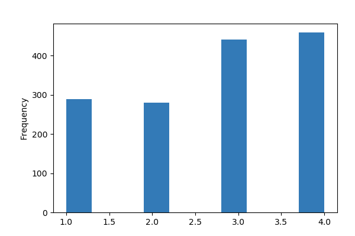

**Common Values**

| Value | Count | Frequency (%) |  |
| --- | --- | --- | --- |
| 4 | 459 | 31.2% |  |
| 3 | 442 | 30.1% |  |
| 1 | 289 | 19.7% |  |
| 2 | 280 | 19.0% |  |

**Extreme Values**

Minimum 5 values

| Value | Count | Frequency (%) |  |
| --- | --- | --- | --- |
| 1 | 289 | 19.7% |  |
| 2 | 280 | 19.0% |  |
| 3 | 442 | 30.1% |  |
| 4 | 459 | 31.2% |  |

Maximum 5 values

| Value | Count | Frequency (%) |  |
| --- | --- | --- | --- |
| 1 | 289 | 19.7% |  |
| 2 | 280 | 19.0% |  |
| 3 | 442 | 30.1% |  |
| 4 | 459 | 31.2% |  |

MaritalStatus  
Categorical

| Distinct count | 3 |
| --- | --- |
| Unique (%) | 0.2% |
| Missing (%) | 0.0% |
| Missing (n) | 0 |

| Married | 673 |
| --- | --- |
| Single | 470 |
| Divorced | 327 |

Toggle details

| Value | Count | Frequency (%) |  |
| --- | --- | --- | --- |
| Married | 673 | 45.8% |  |
| Single | 470 | 32.0% |  |
| Divorced | 327 | 22.2% |  |

MonthlyIncome  
Highly correlated

*This variable is highly correlated with `JobLevel` and should be ignored for analysis*

| Correlation | 0.9503 |
| --- | --- |

MonthlyRate  
Numeric

| Distinct count | 1427 |
| --- | --- |
| Unique (%) | 97.1% |
| Missing (%) | 0.0% |
| Missing (n) | 0 |
| Infinite (%) | 0.0% |
| Infinite (n) | 0 |

| Mean | 14313 |
| --- | --- |
| Minimum | 2094 |
| Maximum | 26999 |
| Zeros (%) | 0.0% |

Toggle details

**Statistics**

Quantile statistics

| Minimum | 2094 |
| --- | --- |
| 5-th percentile | 3384.6 |
| Q1 | 8047 |
| Median | 14236 |
| Q3 | 20462 |
| 95-th percentile | 25432 |
| Maximum | 26999 |
| Range | 24905 |
| Interquartile range | 12414 |

Descriptive statistics

| Standard deviation | 7117.8 |
| --- | --- |
| Coef of variation | 0.49729 |
| Kurtosis | -1.215 |
| Mean | 14313 |
| MAD | 6188.1 |
| Skewness | 0.018578 |
| Sum | 21040262 |
| Variance | 50663000 |
| Memory size | 11.6 KiB |

**Histogram**

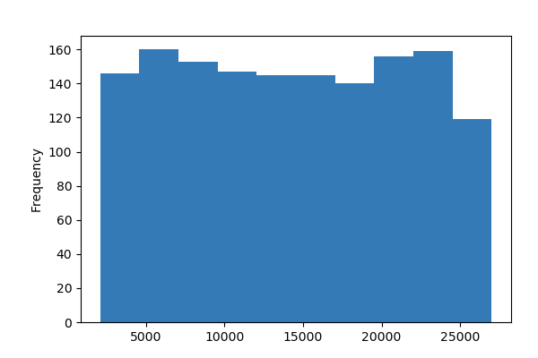

**Common Values**

| Value | Count | Frequency (%) |  |
| --- | --- | --- | --- |
| 4223 | 3 | 0.2% |  |
| 9150 | 3 | 0.2% |  |
| 6670 | 2 | 0.1% |  |
| 7324 | 2 | 0.1% |  |
| 4658 | 2 | 0.1% |  |
| 21534 | 2 | 0.1% |  |
| 16154 | 2 | 0.1% |  |
| 13008 | 2 | 0.1% |  |
| 12355 | 2 | 0.1% |  |
| 6069 | 2 | 0.1% |  |
| Other values (1417) | 1448 | 98.5% |  |

**Extreme Values**

Minimum 5 values

| Value | Count | Frequency (%) |  |
| --- | --- | --- | --- |
| 2094 | 1 | 0.1% |  |
| 2097 | 1 | 0.1% |  |
| 2104 | 1 | 0.1% |  |
| 2112 | 1 | 0.1% |  |
| 2122 | 1 | 0.1% |  |

Maximum 5 values

| Value | Count | Frequency (%) |  |
| --- | --- | --- | --- |
| 26956 | 1 | 0.1% |  |
| 26959 | 1 | 0.1% |  |
| 26968 | 1 | 0.1% |  |
| 26997 | 1 | 0.1% |  |
| 26999 | 1 | 0.1% |  |

NumCompaniesWorked  
Numeric

| Distinct count | 10 |
| --- | --- |
| Unique (%) | 0.7% |
| Missing (%) | 0.0% |
| Missing (n) | 0 |
| Infinite (%) | 0.0% |
| Infinite (n) | 0 |

| Mean | 2.6932 |
| --- | --- |
| Minimum | 0 |
| Maximum | 9 |
| Zeros (%) | 13.4% |

Toggle details

**Statistics**

Quantile statistics

| Minimum | 0 |
| --- | --- |
| 5-th percentile | 0 |
| Q1 | 1 |
| Median | 2 |
| Q3 | 4 |
| 95-th percentile | 8 |
| Maximum | 9 |
| Range | 9 |
| Interquartile range | 3 |

Descriptive statistics

| Standard deviation | 2.498 |
| --- | --- |
| Coef of variation | 0.92753 |
| Kurtosis | 0.010214 |
| Mean | 2.6932 |
| MAD | 2.0598 |
| Skewness | 1.0265 |
| Sum | 3959 |
| Variance | 6.24 |
| Memory size | 11.6 KiB |

**Histogram**

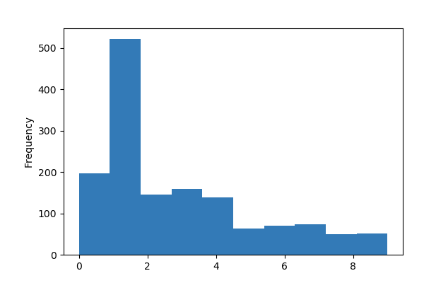

**Common Values**

| Value | Count | Frequency (%) |  |
| --- | --- | --- | --- |
| 1 | 521 | 35.4% |  |
| 0 | 197 | 13.4% |  |
| 3 | 159 | 10.8% |  |
| 2 | 146 | 9.9% |  |
| 4 | 139 | 9.5% |  |
| 7 | 74 | 5.0% |  |
| 6 | 70 | 4.8% |  |
| 5 | 63 | 4.3% |  |
| 9 | 52 | 3.5% |  |
| 8 | 49 | 3.3% |  |

**Extreme Values**

Minimum 5 values

| Value | Count | Frequency (%) |  |
| --- | --- | --- | --- |
| 0 | 197 | 13.4% |  |
| 1 | 521 | 35.4% |  |
| 2 | 146 | 9.9% |  |
| 3 | 159 | 10.8% |  |
| 4 | 139 | 9.5% |  |

Maximum 5 values

| Value | Count | Frequency (%) |  |
| --- | --- | --- | --- |
| 5 | 63 | 4.3% |  |
| 6 | 70 | 4.8% |  |
| 7 | 74 | 5.0% |  |
| 8 | 49 | 3.3% |  |
| 9 | 52 | 3.5% |  |

Over18  
Constant

*This variable is constant and should be ignored for analysis*

| Constant value | Y |
| --- | --- |

OverTime  
Categorical

| Distinct count | 2 |
| --- | --- |
| Unique (%) | 0.1% |
| Missing (%) | 0.0% |
| Missing (n) | 0 |

| No | 1054 |
| --- | --- |
| Yes | 416 |

Toggle details

| Value | Count | Frequency (%) |  |
| --- | --- | --- | --- |
| No | 1054 | 71.7% |  |
| Yes | 416 | 28.3% |  |

PercentSalaryHike  
Numeric

| Distinct count | 15 |
| --- | --- |
| Unique (%) | 1.0% |
| Missing (%) | 0.0% |
| Missing (n) | 0 |
| Infinite (%) | 0.0% |
| Infinite (n) | 0 |

| Mean | 15.21 |
| --- | --- |
| Minimum | 11 |
| Maximum | 25 |
| Zeros (%) | 0.0% |

Toggle details

**Statistics**

Quantile statistics

| Minimum | 11 |
| --- | --- |
| 5-th percentile | 11 |
| Q1 | 12 |
| Median | 14 |
| Q3 | 18 |
| 95-th percentile | 22 |
| Maximum | 25 |
| Range | 14 |
| Interquartile range | 6 |

Descriptive statistics

| Standard deviation | 3.6599 |
| --- | --- |
| Coef of variation | 0.24063 |
| Kurtosis | -0.3006 |
| Mean | 15.21 |
| MAD | 3.0552 |
| Skewness | 0.82113 |
| Sum | 22358 |
| Variance | 13.395 |
| Memory size | 11.6 KiB |

**Histogram**

[12 more figures not shown]

Sample

|  | Age | Attrition | BusinessTravel | DailyRate | Department | DistanceFromHome | Education | EducationField | EmployeeCount | EmployeeNumber | EnvironmentSatisfaction | Gender | HourlyRate | JobInvolvement | JobLevel | JobRole | JobSatisfaction | MaritalStatus | MonthlyIncome | MonthlyRate | NumCompaniesWorked | Over18 | OverTime | PercentSalaryHike | PerformanceRating | RelationshipSatisfaction | StandardHours | StockOptionLevel | TotalWorkingYears | … |
| --- | --- | --- | --- | --- | --- | --- | --- | --- | --- | --- | --- | --- | --- | --- | --- | --- | --- | --- | --- | --- | --- | --- | --- | --- | --- | --- | --- | --- | --- | --- |
| 0 | 41 | Yes | Travel_Rarely | 1102 | Sales | 1 | 2 | Life Sciences | 1 | 1 | 2 | Female | 94 | 3 | 2 | Sales Executive | 4 | Single | 5993 | 19479 | 8 | Y | Yes | 11 | 3 | 1 | 80 | 0 | 8 | … |
| 1 | 49 | No | Travel_Frequently | 279 | Research & Development | 8 | 1 | Life Sciences | 1 | 2 | 3 | Male | 61 | 2 | 2 | Research Scientist | 2 | Married | 5130 | 24907 | 1 | Y | No | 23 | 4 | 4 | 80 | 1 | 10 | … |
| 2 | 37 | Yes | Travel_Rarely | 1373 | Research & Development | 2 | 2 | Other | 1 | 4 | 4 | Male | 92 | 2 | 1 | Laboratory Technician | 3 | Single | 2090 | 2396 | 6 | Y | Yes | 15 | 3 | 2 | 80 | 0 | 7 | … |
| 3 | 33 | No | Travel_Frequently | 1392 | Research & Development | 3 | 4 | Life Sciences | 1 | 5 | 4 | Female | 56 | 3 | 1 | Research Scientist | 3 | Married | 2909 | 23159 | 1 | Y | Yes | 11 | 3 | 3 | 80 | 0 | 8 | … |
| 4 | 27 | No | Travel_Rarely | 591 | Research & Development | 2 | 1 | Medical | 1 | 7 | 1 | Male | 40 | 3 | 1 | Laboratory Technician | 2 | Married | 3468 | 16632 | 9 | Y | No | 12 | 3 | 4 | 80 | 1 | 6 | … |

```python
pandas_profiling.ProfileReport(df)
```

### No Hay valores ausentes, No Valores duplicados en el set de datos.

### Apartir de los Histogramas no se observan valores atípicos (outlayers)

### Atributos con valores constantes: EmployeeCount - Over18 - StandardHours

## Atributos correlacionados: por método de Spearman y Pearson

### Eliminación de atributos correlacionados: MonthlyIncome - TotalWorkingYears

### Eliminación de atributos por no tener carga informativa útil al modelo :

### EmployeeCount - Over18 - StandardHours - EmployeeNumber

```python
df_ = df.drop(['EmployeeCount', 'Over18','StandardHours','EmployeeNumber','TotalWorkingYears','MonthlyIncome'], axis=1)
```

```python
df_.dtypes
```

```
Age                          int64
Attrition                   object
BusinessTravel              object
DailyRate                    int64
Department                  object
DistanceFromHome             int64
Education                    int64
EducationField              object
EnvironmentSatisfaction      int64
Gender                      object
HourlyRate                   int64
JobInvolvement               int64
JobLevel                     int64
JobRole                     object
JobSatisfaction              int64
MaritalStatus               object
MonthlyRate                  int64
NumCompaniesWorked           int64
OverTime                    object
PercentSalaryHike            int64
PerformanceRating            int64
RelationshipSatisfaction     int64
StockOptionLevel             int64
TrainingTimesLastYear        int64
WorkLifeBalance              int64
YearsAtCompany               int64
YearsInCurrentRole           int64
YearsSinceLastPromotion      int64
YearsWithCurrManager         int64
dtype: object
```

```python
df.Attrition.unique()
```

```
array(['Yes', 'No'], dtype=object)
```

```python
target_count = df.Attrition.value_counts()
print('Clase No:', target_count['No'])
print('Clase Yes:', target_count['Yes'])
print('Proposion :', round(target_count[0] / target_count[1], 2), ': 1')
```

```
Clase No: 1233
Clase Yes: 237
Proposion : 5.2 : 1
```

### Como resultado se obtiene un dataset de 1470 instancias y 29 Atributos. Uno de los cuales es el atributo "Clase" : Attrition

### Con el fin de tener un mejor desempeño y a pesar de que los algoritmos de árbol de decisión son tolerantes, tanto a variable numéricas como categóricas, se procede a normalizar los atributos numéricos y a numerizar los valores categóricos, incluido el atributo clase “Attrition”.

```python
df_.shape
```

```
(1470, 29)
```

```python
normalizar_var(df_)
```

```python
numerizar_var(df_)
```

```python
df_.head(20)
```

|  | Age | Attrition | BusinessTravel | DailyRate | Department | DistanceFromHome | Education | EducationField | EnvironmentSatisfaction | Gender | ... | PercentSalaryHike | PerformanceRating | RelationshipSatisfaction | StockOptionLevel | TrainingTimesLastYear | WorkLifeBalance | YearsAtCompany | YearsInCurrentRole | YearsSinceLastPromotion | YearsWithCurrManager |
| --- | --- | --- | --- | --- | --- | --- | --- | --- | --- | --- | --- | --- | --- | --- | --- | --- | --- | --- | --- | --- | --- |
| 0 | 0.446350 | 1 | 2 | 0.742527 | 2 | -1.010909 | -0.891688 | 1 | -0.660531 | 0 | ... | -1.150554 | -0.426230 | -1.584178 | -0.932014 | -2.171982 | -2.493820 | -0.164613 | -0.063296 | -0.679146 | 0.245834 |
| 1 | 1.322365 | 0 | 1 | -1.297775 | 1 | -0.147150 | -1.868426 | 1 | 0.254625 | 1 | ... | 2.129306 | 2.346151 | 1.191438 | 0.241988 | 0.155707 | 0.338096 | 0.488508 | 0.764998 | -0.368715 | 0.806541 |
| 2 | 0.008343 | 1 | 2 | 1.414363 | 1 | -0.887515 | -0.891688 | 4 | 1.169781 | 1 | ... | -0.057267 | -0.426230 | -0.658973 | -0.932014 | 0.155707 | 0.338096 | -1.144294 | -1.167687 | -0.679146 | -1.155935 |
| 3 | -0.429664 | 0 | 1 | 1.461466 | 1 | -0.764121 | 1.061787 | 1 | 1.169781 | 0 | ... | -1.150554 | -0.426230 | 0.266233 | -0.932014 | 0.155707 | 0.338096 | 0.161947 | 0.764998 | 0.252146 | -1.155935 |
| 4 | -1.086676 | 0 | 2 | -0.524295 | 1 | -0.887515 | -1.868426 | 3 | -1.575686 | 1 | ... | -0.877232 | -0.426230 | 1.191438 | 0.241988 | 0.155707 | 0.338096 | -0.817734 | -0.615492 | -0.058285 | -0.595227 |
| 5 | -0.539166 | 0 | 1 | 0.502054 | 1 | -0.887515 | -0.891688 | 1 | 1.169781 | 1 | ... | -0.603911 | -0.426230 | 0.266233 | -0.932014 | -0.620189 | -1.077862 | -0.001333 | 0.764998 | 0.252146 | 0.526188 |
| 6 | 2.417384 | 0 | 2 | 1.292887 | 1 | -0.764121 | 0.085049 | 3 | 0.254625 | 0 | ... | 1.309341 | 2.346151 | -1.584178 | 2.589994 | 0.155707 | -1.077862 | -0.981014 | -1.167687 | -0.679146 | -1.155935 |
| 7 | -0.758170 | 0 | 2 | 1.377177 | 1 | 1.827158 | -1.868426 | 1 | 1.169781 | 1 | ... | 1.855984 | 2.346151 | -0.658973 | 0.241988 | -0.620189 | 0.338096 | -0.981014 | -1.167687 | -0.679146 | -1.155935 |
| 8 | 0.117845 | 0 | 1 | -1.453958 | 1 | 1.703764 | 0.085049 | 1 | 1.169781 | 1 | ... | 1.582663 | 2.346151 | -0.658973 | -0.932014 | -0.620189 | 0.338096 | 0.325228 | 0.764998 | -0.368715 | 1.086895 |
| 9 | -0.101159 | 0 | 2 | 1.230910 | 1 | 2.197341 | 0.085049 | 3 | 0.254625 | 1 | ... | -0.603911 | -0.426230 | -0.658973 | 1.415991 | 0.155707 | -1.077862 | -0.001333 | 0.764998 | 1.493867 | 0.806541 |
| 10 | -0.210661 | 0 | 2 | 0.016150 | 1 | 0.840004 | 0.085049 | 3 | -1.575686 | 1 | ... | -0.603911 | -0.426230 | 0.266233 | 0.241988 | 1.707500 | 0.338096 | -0.327893 | -0.063296 | -0.679146 | -0.314873 |
| 11 | -0.867672 | 0 | 2 | -1.610141 | 1 | 0.716610 | -0.891688 | 1 | 1.169781 | 0 | ... | -0.877232 | -0.426230 | 1.191438 | -0.932014 | 0.155707 | 0.338096 | 0.325228 | 0.212802 | -0.679146 | 1.086895 |
| 12 | -0.648668 | 0 | 2 | -0.328446 | 1 | 2.073946 | -1.868426 | 1 | -1.575686 | 1 | ... | 0.489376 | -0.426230 | 1.191438 | 0.241988 | -1.396086 | -1.077862 | -0.327893 | -0.615492 | 0.562576 | -0.314873 |
| 13 | -0.320163 | 0 | 2 | 1.347427 | 1 | 1.210187 | -0.891688 | 3 | -0.660531 | 1 | ... | -1.150554 | -0.426230 | 0.266233 | 0.241988 | -0.620189 | 0.338096 | -0.817734 | -0.615492 | -0.368715 | -0.595227 |
| 14 | -0.977174 | 1 | 2 | -1.734097 | 1 | 1.827158 | 0.085049 | 1 | 0.254625 | 1 | ... | -0.330589 | -0.426230 | -0.658973 | -0.932014 | 0.931603 | 0.338096 | -0.491174 | -0.615492 | -0.679146 | -0.314873 |
| 15 | -0.867672 | 0 | 2 | 1.454029 | 1 | 1.456975 | 1.061787 | 1 | -0.660531 | 0 | ... | -1.150554 | -0.426230 | 0.266233 | 0.241988 | -1.396086 | 0.338096 | 0.488508 | 1.317193 | 1.804297 | 1.086895 |
| 16 | -0.539166 | 0 | 2 | -1.161424 | 1 | -0.517332 | -0.891688 | 1 | -1.575686 | 1 | ... | -0.877232 | -0.426230 | 1.191438 | 1.415991 | 1.707500 | -1.077862 | -0.164613 | -0.615492 | -0.679146 | 0.245834 |
| 17 | -1.634185 | 0 | 0 | 0.794588 | 1 | 0.840004 | -0.891688 | 3 | 1.169781 | 1 | ... | -0.603911 | -0.426230 | -0.658973 | 1.415991 | -0.620189 | -1.077862 | -0.981014 | -1.167687 | -0.679146 | -1.155935 |
| 18 | 1.760373 | 0 | 2 | 1.032581 | 2 | -0.887515 | 1.061787 | 1 | -1.575686 | 0 | ... | 0.216054 | -0.426230 | 0.266233 | -0.932014 | 0.155707 | 0.338096 | 2.937711 | 1.041095 | 0.252146 | 0.806541 |
| 19 | 0.117845 | 0 | 2 | -1.069697 | 1 | -0.887515 | 0.085049 | 1 | 1.169781 | 1 | ... | -1.150554 | -0.426230 | 0.266233 | -0.932014 | 0.155707 | 0.338096 | -0.654454 | -0.615492 | -0.368715 | -0.595227 |

20 rows × 29 columns

```python
#Desbalance de clases
df_["Attrition"].unique()
```

```
array([1, 0], dtype=int64)
```

```
Clase 0 - No: 1233
Clase 1 - Yes: 237
Proposion : 5.2 : 1
```

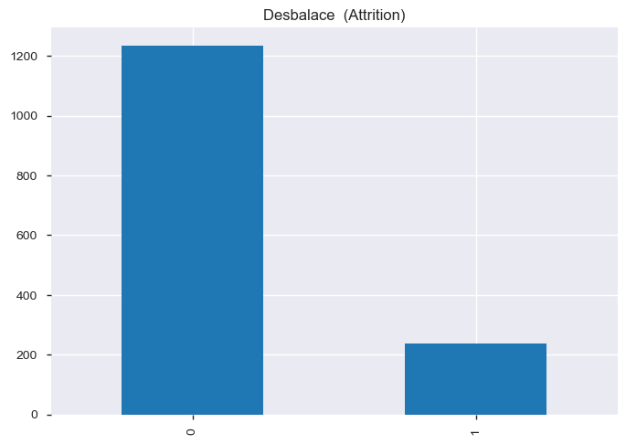

```python
target_count = df_.Attrition.value_counts()
print('Clase 0 - No:', target_count[0])
print('Clase 1 - Yes:', target_count[1])
print('Proposion :', round(target_count[0] / target_count[1], 2), ': 1')

target_count.plot(kind='bar', title='Desbalace  (Attrition)');
```

# Se observa un desbalance de clases

### Este desbalance será controlado en la etapa de entrenamiento del modelo.

## Se obtiene el arreglo de datos (X,y) de atributos y de clase

```python
X = df_.drop(["Attrition"],axis=1)
y = df_["Attrition"]
```

```python
nombres = df_.columns.values.tolist()
nombres =  np.delete(nombres,1)
nombres
```

```
array(['Age', 'BusinessTravel', 'DailyRate', 'Department',
       'DistanceFromHome', 'Education', 'EducationField',
       'EnvironmentSatisfaction', 'Gender', 'HourlyRate',
       'JobInvolvement', 'JobLevel', 'JobRole', 'JobSatisfaction',
       'MaritalStatus', 'MonthlyRate', 'NumCompaniesWorked', 'OverTime',
       'PercentSalaryHike', 'PerformanceRating',
       'RelationshipSatisfaction', 'StockOptionLevel',
       'TrainingTimesLastYear', 'WorkLifeBalance', 'YearsAtCompany',
       'YearsInCurrentRole', 'YearsSinceLastPromotion',
       'YearsWithCurrManager'], dtype='<U24')
```

```python
len(nombres)
```

```
28
```

```python
X.head()
```

|  | Age | BusinessTravel | DailyRate | Department | DistanceFromHome | Education | EducationField | EnvironmentSatisfaction | Gender | HourlyRate | ... | PercentSalaryHike | PerformanceRating | RelationshipSatisfaction | StockOptionLevel | TrainingTimesLastYear | WorkLifeBalance | YearsAtCompany | YearsInCurrentRole | YearsSinceLastPromotion | YearsWithCurrManager |
| --- | --- | --- | --- | --- | --- | --- | --- | --- | --- | --- | --- | --- | --- | --- | --- | --- | --- | --- | --- | --- | --- |
| 0 | 0.446350 | 2 | 0.742527 | 2 | -1.010909 | -0.891688 | 1 | -0.660531 | 0 | 1.383138 | ... | -1.150554 | -0.426230 | -1.584178 | -0.932014 | -2.171982 | -2.493820 | -0.164613 | -0.063296 | -0.679146 | 0.245834 |
| 1 | 1.322365 | 1 | -1.297775 | 1 | -0.147150 | -1.868426 | 1 | 0.254625 | 1 | -0.240677 | ... | 2.129306 | 2.346151 | 1.191438 | 0.241988 | 0.155707 | 0.338096 | 0.488508 | 0.764998 | -0.368715 | 0.806541 |
| 2 | 0.008343 | 2 | 1.414363 | 1 | -0.887515 | -0.891688 | 4 | 1.169781 | 1 | 1.284725 | ... | -0.057267 | -0.426230 | -0.658973 | -0.932014 | 0.155707 | 0.338096 | -1.144294 | -1.167687 | -0.679146 | -1.155935 |
| 3 | -0.429664 | 1 | 1.461466 | 1 | -0.764121 | 1.061787 | 1 | 1.169781 | 0 | -0.486709 | ... | -1.150554 | -0.426230 | 0.266233 | -0.932014 | 0.155707 | 0.338096 | 0.161947 | 0.764998 | 0.252146 | -1.155935 |
| 4 | -1.086676 | 2 | -0.524295 | 1 | -0.887515 | -1.868426 | 3 | -1.575686 | 1 | -1.274014 | ... | -0.877232 | -0.426230 | 1.191438 | 0.241988 | 0.155707 | 0.338096 | -0.817734 | -0.615492 | -0.058285 | -0.595227 |

5 rows × 28 columns

```python
df_.dtypes
```

```
Age                         float64
Attrition                     int64
BusinessTravel                int64
DailyRate                   float64
Department                    int64
DistanceFromHome            float64
Education                   float64
EducationField                int64
EnvironmentSatisfaction     float64
Gender                        int64
HourlyRate                  float64
JobInvolvement              float64
JobLevel                    float64
JobRole                       int64
JobSatisfaction             float64
MaritalStatus                 int64
MonthlyRate                 float64
NumCompaniesWorked          float64
OverTime                      int64
PercentSalaryHike           float64
PerformanceRating           float64
RelationshipSatisfaction    float64
StockOptionLevel            float64
TrainingTimesLastYear       float64
WorkLifeBalance             float64
YearsAtCompany              float64
YearsInCurrentRole          float64
YearsSinceLastPromotion     float64
YearsWithCurrManager        float64
dtype: object
```

```python
X=np.array(X)
y= np.array(y)
```

```python
X.shape
```

```
(1470, 28)
```

```python
y.shape
```

```
(1470,)
```

# Clasificación Random Forest

```python
X_train, X_test, y_train, y_test = train_test_split(X,y,test_size=0.3, random_state=2)
```

## Busqueda mejores parámetros con gridsearch

### Parámetros: Peso de clases , y número de estimadores

```python
param_grid = {'class_weight':['balanced',{1:5},{1:10},{1:15},{1:20}],'n_estimators':[10,20,30,50,100,200,250,300], 'random_state':[2]}
grid_search = GridSearchCV(RandomForestClassifier(), param_grid, cv=5)
grid_search.fit(X_train, y_train)
print("Test set score: {:.2f}".format(grid_search.score(X_test, y_test)))
print("Best parameters: {}".format(grid_search.best_params_))
print("Best cross-validation score: {:.2f}".format(grid_search.best_score_))
print("Best estimator:\n{}".format(grid_search.best_estimator_))
```

```
Test set score: 0.86
Best parameters: {'class_weight': {1: 5}, 'n_estimators': 200, 'random_state': 2}
Best cross-validation score: 0.85
Best estimator:
RandomForestClassifier(bootstrap=True, class_weight={1: 5}, criterion='gini',
                       max_depth=None, max_features='auto', max_leaf_nodes=None,
                       min_impurity_decrease=0.0, min_impurity_split=None,
                       min_samples_leaf=1, min_samples_split=2,
                       min_weight_fraction_leaf=0.0, n_estimators=200,
                       n_jobs=None, oob_score=False, random_state=2, verbose=0,
                       warm_start=False)
```

```python
forest1 = RandomForestClassifier(class_weight= {1: 5}, n_estimators= 200, random_state=2)
forest1.fit(X_train, y_train)
eval_modelo(forest1)
```

```
Train Accuracy: 1.0
Test Accuracy : 0.8571428571428571
F1 score +    : 0.24096385542168677
Recall +      : 0.14084507042253522
Precision +   : 0.8333333333333334

 clasification report:
               precision    recall  f1-score   support

           0       0.86      0.99      0.92       370
           1       0.83      0.14      0.24        71

    accuracy                           0.86       441
   macro avg       0.85      0.57      0.58       441
weighted avg       0.85      0.86      0.81       441


 Matriz de Confusion:
 [[368   2]
 [ 61  10]]
```

### Parámetros: numero de atributos seleccionados para la división de cada arbol y número de estimadores

```python
param_grid = {'max_features':[5,10,15,20,25,28],'n_estimators':[10,20,30,50,100,200,250,300],'random_state':[2]}
grid_search = GridSearchCV(RandomForestClassifier(), param_grid, cv=5)
grid_search.fit(X_train, y_train)
print("Test set score: {:.2f}".format(grid_search.score(X_test, y_test)))
print("Best parameters: {}".format(grid_search.best_params_))
print("Best cross-validation score: {:.2f}".format(grid_search.best_score_))
print("Best estimator:\n{}".format(grid_search.best_estimator_))
```

```
Test set score: 0.86
Best parameters: {'max_features': 20, 'n_estimators': 200, 'random_state': 2}
Best cross-validation score: 0.86
Best estimator:
RandomForestClassifier(bootstrap=True, class_weight=None, criterion='gini',
                       max_depth=None, max_features=20, max_leaf_nodes=None,
                       min_impurity_decrease=0.0, min_impurity_split=None,
                       min_samples_leaf=1, min_samples_split=2,
                       min_weight_fraction_leaf=0.0, n_estimators=200,
                       n_jobs=None, oob_score=False, random_state=2, verbose=0,
                       warm_start=False)
```

```python
forest2 = RandomForestClassifier(max_features = 20, n_estimators=200, random_state=2)
forest2.fit(X_train, y_train)
eval_modelo(forest2)
```

```
Train Accuracy: 1.0
Test Accuracy : 0.8594104308390023
F1 score +    : 0.3404255319148936
Recall +      : 0.22535211267605634
Precision +   : 0.6956521739130435

 clasification report:
               precision    recall  f1-score   support

           0       0.87      0.98      0.92       370
           1       0.70      0.23      0.34        71

    accuracy                           0.86       441
   macro avg       0.78      0.60      0.63       441
weighted avg       0.84      0.86      0.83       441


 Matriz de Confusion:
 [[363   7]
 [ 55  16]]
```

```
[0 1]
```

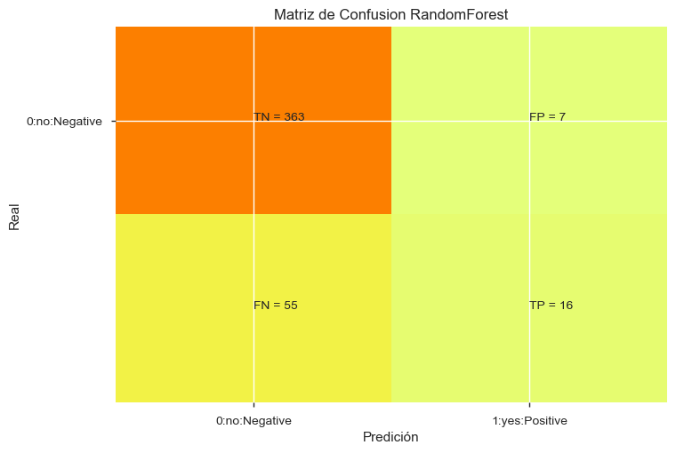

```python
plt.clf()
plt.imshow(cm1, interpolation='none', aspect='auto',cmap=plt.cm.Wistia)
classNames = ['0:no:Negative', '1:yes:Positive']
plt.title('Matriz de Confusion RandomForest')
plt.ylabel('Real')
plt.xlabel('Predición')
tick_marks = np.arange(len(classNames))
print(tick_marks)
plt.xticks(tick_marks, classNames)
plt.yticks(np.arange(0,1), classNames)
s = [['TN','FP'], ['FN', 'TP']]
for i in range(2):
    for j in range(2):
        plt.text(j,i, str(s[i][j])+" = "+str(cm1[i][j]))
plt.show()
```

### De acuerdo con las especificaciones de algoritmo RandomForest el parametro max_features para efectos de clasificación puede ser : max_features = sqrt(n_features).

```python
forest3 = RandomForestClassifier(max_features= 5, n_estimators= 200, random_state=2)
forest3.fit(X_train, y_train)
eval_modelo(forest3)
```

```
Train Accuracy: 1.0
Test Accuracy : 0.8684807256235828
F1 score +    : 0.34090909090909094
Recall +      : 0.2112676056338028
Precision +   : 0.8823529411764706

 clasification report:
               precision    recall  f1-score   support

           0       0.87      0.99      0.93       370
           1       0.88      0.21      0.34        71

    accuracy                           0.87       441
   macro avg       0.88      0.60      0.63       441
weighted avg       0.87      0.87      0.83       441


 Matriz de Confusion:
 [[368   2]
 [ 56  15]]
```

## Importancia de Variables

```python
feature_list = sorted(zip(map(lambda x: round(x, 2), forest3.feature_importances_), nombres),reverse=True)

print('feature\t\t\ttimportance')
print("\n".join(['{}\t\t\t{}'.format(f,i) for i,f in feature_list]))
print('total_importance\t\t\t\t',  sum([i for i,f in feature_list]))
```

```
feature			timportance
Age			0.08
DailyRate			0.07
MonthlyRate			0.06
YearsAtCompany			0.05
OverTime			0.05
HourlyRate			0.05
DistanceFromHome			0.05
YearsWithCurrManager			0.04
StockOptionLevel			0.04
PercentSalaryHike			0.04
NumCompaniesWorked			0.04
EnvironmentSatisfaction			0.04
YearsSinceLastPromotion			0.03
YearsInCurrentRole			0.03
WorkLifeBalance			0.03
TrainingTimesLastYear			0.03
RelationshipSatisfaction			0.03
MaritalStatus			0.03
JobSatisfaction			0.03
JobRole			0.03
JobLevel			0.03
JobInvolvement			0.03
EducationField			0.03
Education			0.02
BusinessTravel			0.02
PerformanceRating			0.01
Gender			0.01
Department			0.01
total_importance				 1.0100000000000002
```

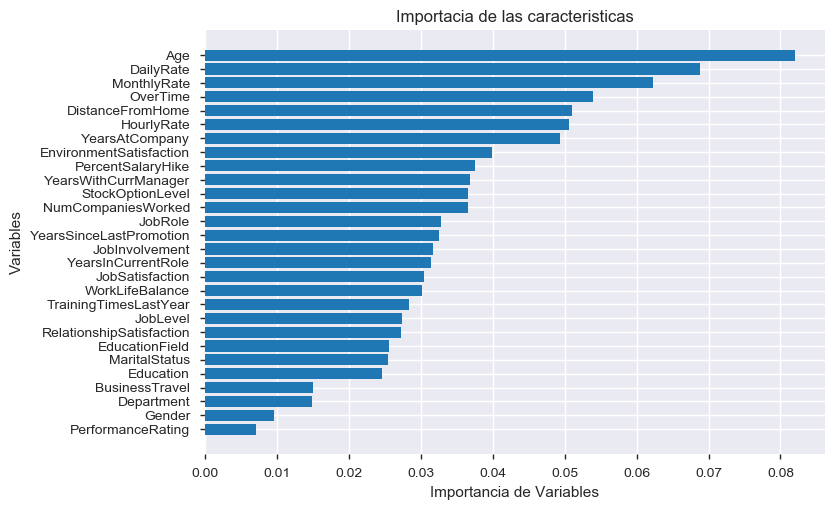

```python
imp = forest3.feature_importances_
#print(imp)
#nombres = data_normal.column
imp,nombres1 = zip(*sorted(zip(imp,nombres)))
plt.barh(range(len(nombres1)),imp, align='center')
plt.yticks(range(len(nombres1)),nombres1)
plt.xlabel('Importancia de Variables')
plt.ylabel('Variables')
plt.title("Importacia de las caracteristicas")
plt.show()
```

### De los resultados obtenidos se observa el modelo forest3 podría ser un buen modelo con precisión =87% y el recall=99% para la clase Negativa (0-NO), que son muy buenos indicadores, entre tanto la precisión=88% para la clase positiva (1-YES) , y su recall =21% lo cual es muy bajo.

### De acuerdo con las condiciones del negocio sería deseable tener un mayor recall en la clase positiva, con el fin de identificar con suficiente antelación los empleados que podrían considerar el abandono de sus puestos de trabajo

# Determinar mejores métricas para la clase positiva.

### Con el fin de lograr mejores métricas de la clase positiva, utilizaremos el umbral de las probabilidades generadas por RandomForest para cada clase , mediante la función predict_proba

### función predict_proba determina la probabilidad de pertenencia se una instancia a cada clase, por lo cual cada instancia, en clasificación binaria tiene dos probabilidades.

### El umbral es 0.5 con lo cual asigna la clase a la instancia cuya probabilidad este por encima de este valor.

### Podemos variar el umbral de la probabilidad para obtener mejores resultados en recall de la clase positiva, para ello se puede utilizar "precision_recall_curve"

```python
print("Shape de  probabilidad de cada clase: {}".format(forest3.predict_proba(X_test).shape))
```

```
Shape de  probabilidad de cada clase: (441, 2)
```

### La probabilidad de perterncia a la clase positva: forest3.predict_proba(X_test)[:, 1]

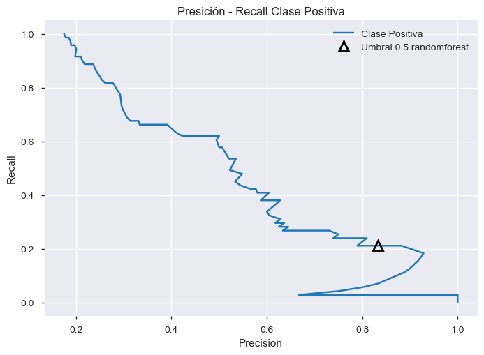

```python
from sklearn.metrics import precision_recall_curve
precision_rf, recall_rf, thresholds_rf = precision_recall_curve(
y_test, forest3.predict_proba(X_test)[:, 1])
plt.plot(precision_rf, recall_rf, label="Clase Positiva")
close_default_rf = np.argmin(np.abs(thresholds_rf - 0.5))
plt.plot(precision_rf[close_default_rf], recall_rf[close_default_rf], '^', c='k',
markersize=10, label="Umbral 0.5 randomforest", fillstyle="none", mew=2)
plt.xlabel("Precision")
plt.ylabel("Recall")
plt.title("Presición - Recall Clase Positiva")
plt.legend(loc="best")
```

### Se observa que el recall=21% de la clase positiva es muy bajo con el umbral 0.5

### Variando el umbral de probabilidad.

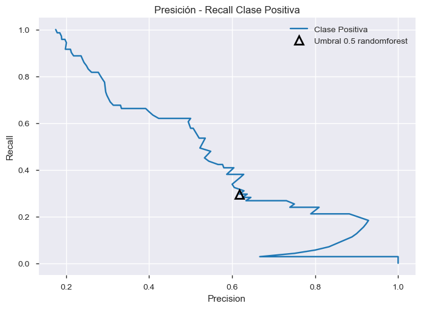

```python
precision_rf, recall_rf, thresholds_rf = precision_recall_curve(
y_test, forest3.predict_proba(X_test)[:, 1])
plt.plot(precision_rf, recall_rf, label="Clase Positiva")
close_default_rf = np.argmin(np.abs(thresholds_rf - 0.4))
plt.plot(precision_rf[close_default_rf], recall_rf[close_default_rf], '^', c='k',
markersize=10, label="Umbral 0.5 randomforest", fillstyle="none", mew=2)
plt.xlabel("Precision")
plt.ylabel("Recall")
plt.title("Presición - Recall Clase Positiva")
plt.legend(loc="best")
```

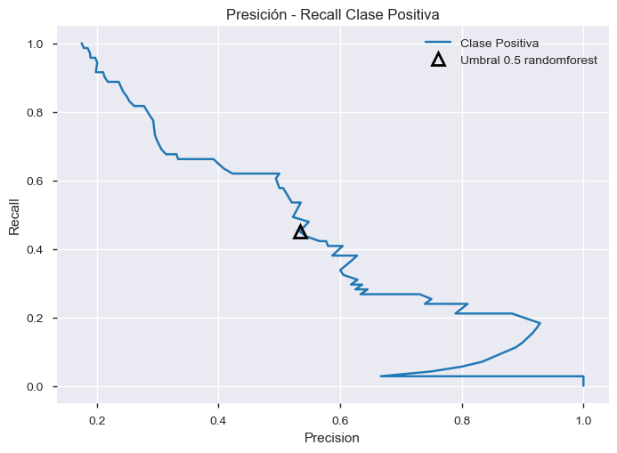

```python
precision_rf, recall_rf, thresholds_rf = precision_recall_curve(
y_test, forest3.predict_proba(X_test)[:, 1])
plt.plot(precision_rf, recall_rf, label="Clase Positiva")
close_default_rf = np.argmin(np.abs(thresholds_rf - 0.3))
plt.plot(precision_rf[close_default_rf], recall_rf[close_default_rf], '^', c='k',
markersize=10, label="Umbral 0.5 randomforest", fillstyle="none", mew=2)
plt.xlabel("Precision")
plt.ylabel("Recall")
plt.title("Presición - Recall Clase Positiva")
plt.legend(loc="best")
```

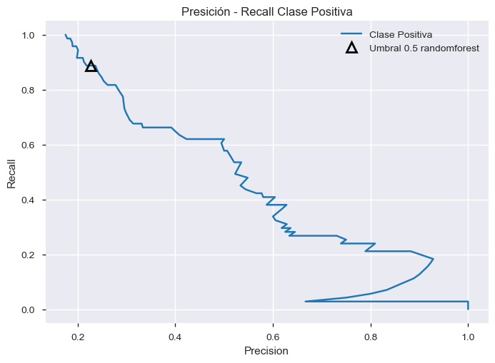

```python
precision_rf, recall_rf, thresholds_rf = precision_recall_curve(
y_test, forest3.predict_proba(X_test)[:, 1])
plt.plot(precision_rf, recall_rf, label="Clase Positiva")
close_default_rf = np.argmin(np.abs(thresholds_rf - 0.1))
plt.plot(precision_rf[close_default_rf], recall_rf[close_default_rf], '^', c='k',
markersize=10, label="Umbral 0.5 randomforest", fillstyle="none", mew=2)
plt.xlabel("Precision")
plt.ylabel("Recall")
plt.title("Presición - Recall Clase Positiva")
plt.legend(loc="best")
```

# Se observa como variando el umbral de decisión o probabilidad es posible tener mejores resultados en recall y desde luego penalizando la precisión de esta clase.

## De igual forma podemos ver la relación entre entre la Rata de Falsos Positivos (la proporción de lo que clasifico mal de la clase negativa (0)-> FPR ) y el Recall de la clase positiva (recall clase positiva 1 -> TPR), utilizando ROC curve.

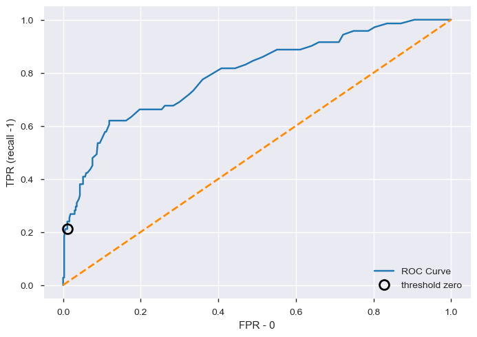

```python
from sklearn.metrics import roc_curve
probas_ = forest3.predict_proba(X_test)
fpr, tpr, thresholds = roc_curve(y_test, probas_[:, 1])
#print(thresholds)
plt.plot(fpr, tpr, label="ROC Curve")
plt.xlabel("FPR - 0")
plt.ylabel("TPR (recall -1)")
# find threshold closest to zero
close_zero = np.argmin(np.abs(thresholds-0.5))
plt.plot(fpr[close_zero], tpr[close_zero], 'o', markersize=10,
label="threshold zero", fillstyle="none", c='k', mew=2)
plt.plot([0, 1], [0, 1], color='darkorange', lw=2, linestyle='--')
plt.legend(loc=4)
```

### Con ROC-CURVE, y umbral 0.5, se observa que el recall de la clase positiva es muy bajo, pero aumentar el recall implica un aumento en la taza de falsos positivos de la clase negativa (0-No), como se observa en al siguiente grafica

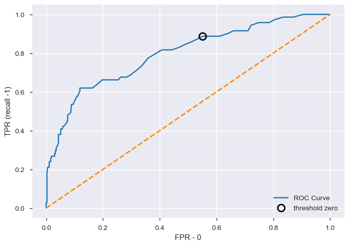

```python
probas_ = forest3.predict_proba(X_test)
fpr, tpr, thresholds = roc_curve(y_test, probas_[:, 1])
#print(thresholds)
plt.plot(fpr, tpr, label="ROC Curve")
plt.xlabel("FPR - 0")
plt.ylabel("TPR (recall -1)")
# find threshold closest to zero
close_zero = np.argmin(np.abs(thresholds-0.1))
plt.plot(fpr[close_zero], tpr[close_zero], 'o', markersize=10,
label="threshold zero", fillstyle="none", c='k', mew=2)
plt.plot([0, 1], [0, 1], color='darkorange', lw=2, linestyle='--')
plt.legend(loc=4)
```

```python
from sklearn.metrics import roc_auc_score
svc_auc = roc_auc_score(y_test, probas_[:, 1])
print("Area bajo la cuva ROC o  Presición promedio",svc_auc)
print("Tiene en cuenta el desbalance de clases")
```

```
Area bajo la cuva ROC o  Presición promedio 0.7952797868290826
Tiene en cuenta el desbalance de clases
```

# En conclusión podemos utilizar este procedimiento para mejora el recall de la clase positiva para cumplir con el requerimiento del negocio.

# Tenemos en y_pred_lower_threshold1 las instancias de los empleados que podrían considerar el abandono de sus puestos de trabajo.

## Métricas asociadas a este nuevo umbral

```python
y_pred_lower_threshold1 = forest3.predict_proba(X_test) >0.1
print(classification_report(y_test, y_pred_lower_threshold1[:,1]))
```

```
              precision    recall  f1-score   support

           0       0.95      0.45      0.61       370
           1       0.24      0.89      0.37        71

    accuracy                           0.52       441
   macro avg       0.59      0.67      0.49       441
weighted avg       0.84      0.52      0.57       441
```

# Se observa mejor recall clase positiva , pero igualmente penalización en precisión y en la taza de falsos positivos

## Comparación con Arbol de desición

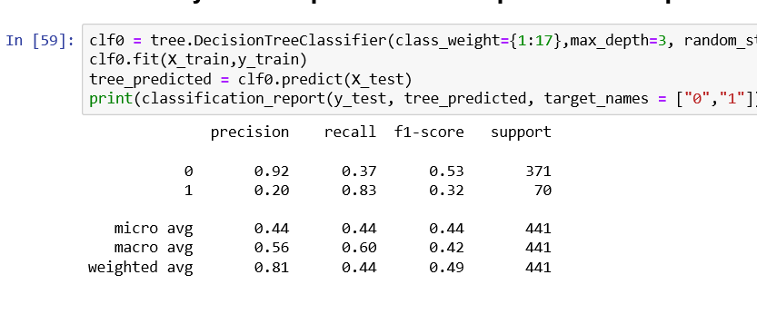

## Con RandomForest, se observa en general un mejor desempeño en recall, en comparación con los arboles de desición.